# Table of Contents

```python
# Import pacakges

import numpy as np
import math
import matplotlib.pyplot as plt
import pandas as pd
import statsmodels.api as sm
import statsmodels.formula.api as smf
from statsmodels.iolib.summary2 import summary_col
```

```python
# Import datasets

carfeatures = pd.read_csv("data/features.csv")
results_raw  = pd.read_csv("data_raw/results.csv")
results = pd.read_csv("data_raw/results.csv")
races_raw    = pd.read_csv("data_raw/races.csv")
circuits_raw = pd.read_csv("data_raw/circuits.csv")
circuits = pd.read_csv("data_raw/circuits.csv")
```

```python
# Global Codes

np.random.seed(5120)
```

## Python Basics

### Variables and Data Types

We use the function `type()` to identify the type of object: integers (`int`), floats, or strings (`str`).

```python
type(3)
```

```
int
```

```python
type(3.5)
```

```
float
```

```python
type("hello")
```

```
str
```

### Basic Operations on Integers and Floats

```python
print(3 * 2)
print(3 + 2)
print(3 - 2)
print(3 / 2)
print(3 ** 2) # Exponentiation
```

```
6
5
1
1.5
9
```

We can use `()` for composite operations

```python
(3 + 4) / 5
```

```
1.4
```

We can assign values to variables and apply operators on variables.

```python
number3        = 3
number3andhalf = 3.5
message_hello  = "hello"
```

```python
print(number3 * 2)
print(number3andhalf ** 2)
print( (number3 + 4) / 5 )
```

```
6
12.25
1.4
```

Concatenate ("add") two strings

```python
name = "Jiuru"

print("My name is "  + name)
```

```
My name is Jiuru
```

### Lists

We use `[...]` to denote lists. Elements in lists are separated by commas.

```python
list_numbers     = [1, 2, 3, 4, 5]
list_numbers_sqr = [1, 4, 9, 16, 25]
```

The type of elements in a list can be anything.

```python
list_colors = ["red", "yellow", "yellow", "green", "red"]
list_mixedtype = ["red", 1, "yellow", 4, 5]
```

To extract individual elements from a list, we need to understand python lists start at the zero position. In other words, the first element in the list has an index of `0`. We use `[index]` to extract elements from a list

```python
floors_england = ["ground", "floor1", "floor2" ]

print(floors_england[0])
print(floors_england[1])
print(floors_england[2])
```

```
ground
floor1
floor2
```

```python
# Recall the list_colors we defined before

print(list_colors[0])
print(list_colors[1])
print(list_colors[2])
print(list_colors[3])
print(list_colors[4])
```

```
red
yellow
yellow
green
red
```

We can create lists with `null` values.

```python
list_answers = [None,None,None]

print(list_answers)
```

```
[None, None, None]
```

Now, we can assigning or replacing values to lists

```python
list_answers[0] = "Atlanta"
list_answers[1] = "Chicago"
list_answers[2] = "Boston"

print(list_answers)
```

```
['Atlanta', 'Chicago', 'Boston']
```

We can use `[]` to create an empty list and use `list.append()` to append values to lists.

```python
new_list = []
new_list.append("Tuesday")
new_list.append("Wednesday")
new_list.append("Thursday")
new_list.append("Friday")
new_list.append("Saturday")

print(new_list)
```

```
['Tuesday', 'Wednesday', 'Thursday', 'Friday', 'Saturday']
```

We can create lists with repeated values by multiply as list with an integer

```python
# Repeat a single value 30 times
list_two_rep = [7] * 30

# Repeat a list 4 times
list_answers_rep = list_answers * 4

# Repeat of 8 null values
list_none_rep = [None] * 8


print(list_two_rep)
print(list_answers_rep)
print(list_none_rep)
```

```
[7, 7, 7, 7, 7, 7, 7, 7, 7, 7, 7, 7, 7, 7, 7, 7, 7, 7, 7, 7, 7, 7, 7, 7, 7, 7, 7, 7, 7, 7]
['Atlanta', 'Chicago', 'Boston', 'Atlanta', 'Chicago', 'Boston', 'Atlanta', 'Chicago', 'Boston', 'Atlanta', 'Chicago', 'Boston']
[None, None, None, None, None, None, None, None]
```

We can use the function `len()` to count the length of a list

```python
print(len(list_answers))
print(len(list_two_rep))
print(len(list_answers_rep))
```

```
3
30
12
```

***Exercise***

- Create an empty list called "list_personal"
- Add two more values using ".append"
- Find the total length of the list
- Change the last value to "Last element"

```python
list_personal = []
list_personal.append("Hello")
list_personal.append("World")

print(len(list_personal))

# There are two ways to change the last value of a list:
list_personal[-1] = "Last element"
list_personal[len(list_personal)-1] = "Last element"

list_personal
```

```
2
```

```
['Hello', 'Last element']
```

***Note***: `list[-1]` calls the last element in the list.

We can use `list(range(n))` to create a list from `0` to `n-1`.

```python
n = 10
list_zero_ten = list(range(n))
print(list_zero_ten)
```

```
[0, 1, 2, 3, 4, 5, 6, 7, 8, 9]
```

### Boolean Variables

We can use `==` to test the equality of two strings.

```python
"Is this the real life?" == "is this just fantasy?"
```

```
False
```

```python
# Another example

any_questions = "no"
print(any_questions == "yes" )
```

```
False
```

To test for the presence of keywords in a sentence, we use `in`. The syntax is

```
keyword in sentence
```

```python
keyword = "alejandro"
sentence = "The Federal Reserve makes forecasts about many economic outcomes"

keyword in sentence
```

```
False
```

We can also use `in` to test whether an element is a part of a list.

```python
current_month      = "July"
list_summer_months = ["June","July","August"]

print(current_month in list_summer_months)
```

```
True
```

***Exercise***

Write code to check whether the string "red" is contained in the list

```
["red","green","yellow","orange"]
```

```python
color = "red"
color_list = ["red", "green", "yellow", "orange"]

print(color in color_list)
```

```
True
```

When testing with numbers, we have:

- Strictly less than (<), less than or equal (<=)
- Equal (==)
- Strictly more than (>), greater than or equal to (>=)

```python
x = 4

print(x < 5)
print(x <= 5)
print(x == 5)
print(x >= 5)
print(x > 5)
```

```
True
True
False
False
False
```

If we want to validate a data type, we can use the `isinstance()` function. The syntax is

```
isinstance(x, type)
```

```python
y = "Monday"

print(isinstance(y, int))
print(isinstance(y, float))
print(isinstance(y, str))
```

```
False
False
True
```

Equality of vectors is done element-by-element

```python
vec_a = np.array([1,2,3])
vec_b = np.array([1,2,4])

vec_a == vec_b
```

```
array([ True,  True, False])
```

When testing multiple expressions, we have `not`, `and` (`&`), and `or` (`|`).

```python
age  = 10

# Can this person legally vote in the US?
print(age >= 18)
print(not (age < 18))
```

```
False
False
```

```python
age = 31

# Is this age between 20 and 30 (including these ages)?
( age >= 20 ) & (age <= 30)
```

```
False
```

```python
student_status = "freshman"

# Is the student in the first two years of undergrad?
(student_status == "freshman") | (student_status == "sophomore")
```

```
True
```

***Exercise***

Write code that checks the following conditions:

- Whether age is strictly less than 20, or greater than 30
- Not in the age range 25-27

```python
age = 28

print(age < 20 & age > 30)
print(not((age >= 25) & (age <= 27)))
```

```
False
True
```

```python
list_boolean = [True,False,True,False,False]
np.mean(list_boolean)
```

```
0.4
```

### Flow Control (`if`/`elif`/`else`)

The following is the syntax for flow control:

```
if condition:
    body_statement_1
elif condition:
    body_statement_2
elif condition:
    body_statment_3
...
else:
    body_statement_4
```

```python
any_questions = "yes"

if any_questions == "yes":
    print("Need to give more explanations")
```

```
Need to give more explanations
```

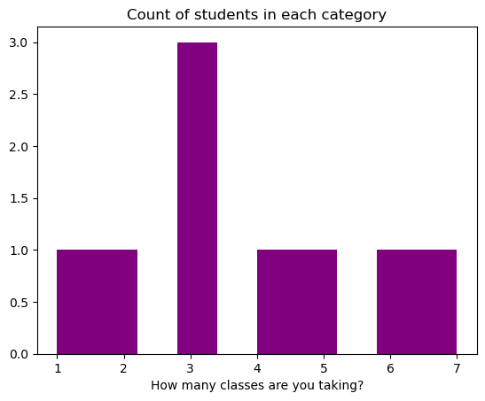

```python
is_graph_red     = False
how_many_classes = np.array([7,1,2,3,3,3,4,5,6])

if is_graph_red:
    plt.hist(x = how_many_classes, color="red")
    plt.title("Count of students in each category")
    plt.xlabel("How many classes are you taking?")
    plt.show()
else:
    plt.hist(x = how_many_classes, color="purple")
    plt.title("Count of students in each category")
    plt.xlabel("How many classes are you taking?")
    plt.show()
```

```python
years_in_program = 4

if years_in_program == 1:
    print("This student is a freshman")
elif years_in_program == 2:
    print("This student is a sophomore")
elif years_in_program == 3:
    print("This student is a junior")
else:
    print("This student is a senior")
```

```
This student is a senior
```

***Exercise***

- Create a numeric vector, $ c = \begin{pmatrix} 1 \\ 2 \\ 3 \end{pmatrix} $
- Use the "sum()"' function to add up the individual elements.
- If the sum of numbers is higher than $5$, write a message saying

" The sum is greater than or equal to 5"

- Otherwise show a message "It is strictly less than 5"

```python
c = np.array([1, 2, 3])

if sum(c) >= 5:
    print("The sum is greater than or equal to 5")
else:
    print("It is strictly less than 5")
```

```
The sum is greater than or equal to 5
```

### `for` Loops

This is the basic syntax for a for loop:

```
for value in list_values:
    statement_body
```

```python
list_ids = ["KIA", "Ferrari", "Ford", "Tesla"]

for id in list_ids:
    print(f"Dear customer, we are writing about your {id} car.")
```

```
Dear customer, we are writing about your KIA car.
Dear customer, we are writing about your Ferrari car.
Dear customer, we are writing about your Ford car.
Dear customer, we are writing about your Tesla car.
```

```python
# Customized Message + Numbering

list_ids = ["KIA", "Ferrari", "Ford", "Tesla"]

index = 1
for id in list_ids:
    print(f"Dear customer, your position is {str(index)} on the waitlist and your car brand is {id}")
    index += 1
```

```
Dear customer, your position is 1 on the waitlist and your car brand is KIA
Dear customer, your position is 2 on the waitlist and your car brand is Ferrari
Dear customer, your position is 3 on the waitlist and your car brand is Ford
Dear customer, your position is 4 on the waitlist and your car brand is Tesla
```

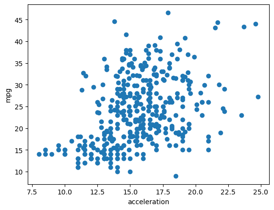

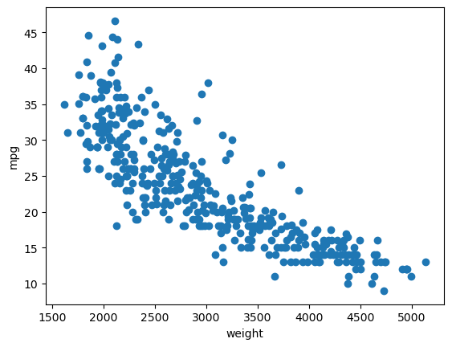

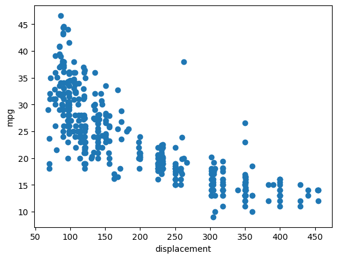

```python
# Plot Multiple Variables

carfeatures = pd.read_csv("data/features.csv")
list_vars   = ["acceleration", "weight", "displacement"]

for variable_name in list_vars:
    plt.scatter(x= carfeatures[variable_name], y = carfeatures["mpg"])
    plt.ylabel("mpg")
    plt.xlabel(variable_name)
    plt.show()
```

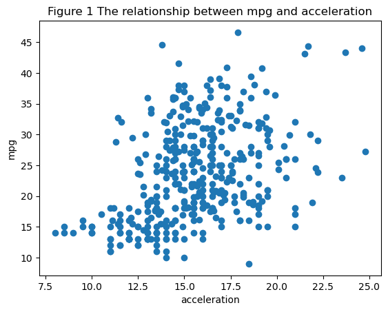

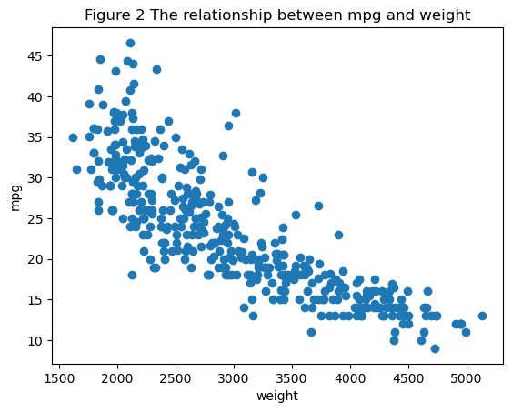

```python
# Plots for Multiple Variables + Numbering

carfeatures = pd.read_csv("data/features.csv")
list_vars   = ["acceleration","weight"]

index = 1
for variable_name in list_vars:
    plt.scatter(x= carfeatures[variable_name], y = carfeatures["mpg"])
    plt.ylabel("mpg")
    plt.xlabel(variable_name)
    plt.title(f"Figure {str(index)} The relationship between mpg and {str(variable_name)}")
    plt.show()
    index += 1
```

```
[3, 8, 24, 35, 48, 63, 80, 99, 120]
```

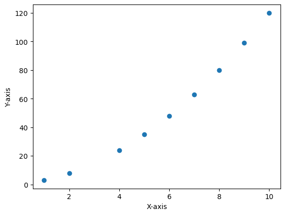

```python
# Math Operationg (Appending)

n = 50
list_x = [1,2,4,5,6,7,8,9,10]
list_y = []

# Create an index

index = 0
for x in list_x:
    y = list_x[index]**2 + 2*x
    list_y.append(y)
    index = index + 1

print(list_y)
plt.scatter(list_x, list_y)
plt.xlabel("X-axis")
plt.ylabel("Y-axis")
```

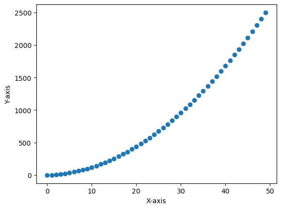

```python
# Or we can use NumPy array to complete the task

list_x = np.arange(50)
list_y = list_x**2 + 2*list_x

plt.scatter(list_x, list_y)
plt.xlabel("X-axis")
plt.ylabel("Y-axis")
```

```
[1, 4, 9, 16, 25, 36, 49, 64, 81, 100, 121, 144, 169, 196, 225, 256, 289, 324, 361, 400, 441, 484, 529, 576, 625, 676, 729, 784, 841, 900, 961, 1024, 1089, 1156, 1225, 1296, 1369, 1444, 1521, 1600, 1681, 1764, 1849, 1936, 2025, 2116, 2209, 2304, 2401]
```

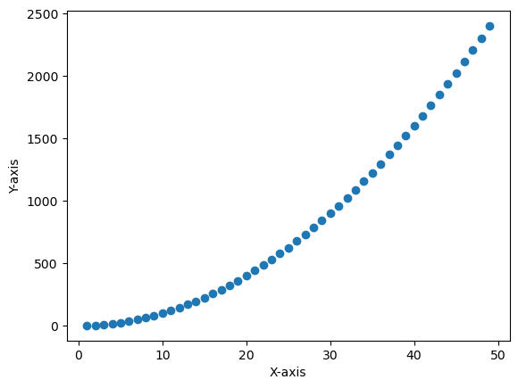

```python
# Math Operations + Numbering (Filling)
# Create a list of x-values list_x = [1,2,4,5, ..., 50]
# Create a list of y-values to fill in later.

n = 50
list_x = list(range(1,n,1))
list_y = [None] * len(list_x)

# Create an index
index = 0
for x in list_x:
    list_y[index] = list_x[index]**2
    index += 1

print(list_y)
plt.scatter(list_x, list_y)
plt.xlabel("X-axis")
plt.ylabel("Y-axis")
```

***Exercise***

- Create a histogram and number the figures for each of the variables:

```
list_variables = ["weight", "acceleration","mpg"]
```

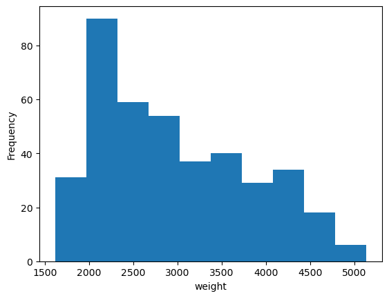

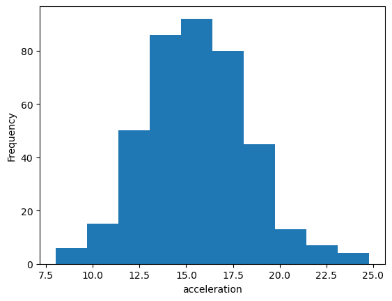

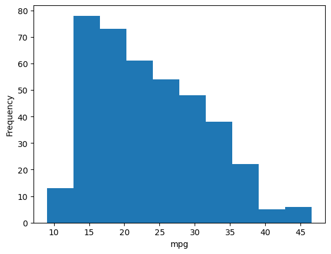

```python
list_variables = ["weight", "acceleration", "mpg"]

for variable in list_variables:
    plt.hist(x = carfeatures[variable])
    plt.ylabel("Frequency")
    plt.xlabel(str(variable))
    plt.show()
```

***Exercise***

- Create a new object called

```
list_datasets = ["features.csv","worldbank_wdi_2019.csv"]
```

- Run a for loop over this list:
- Read each of the datasets using "pd.read_csv()"
- Print a table of descriptive statistics for each dataset

```python
list_datasets = ["features.csv", "worldbank_wdi_2019.csv"]

for dataset in list_datasets:
    df = pd.read_csv(f"data/{dataset}")
    print(df.describe())
```

```
              mpg   cylinders  displacement       weight  acceleration
count  398.000000  398.000000    398.000000   398.000000    398.000000
mean    23.514573    5.454774    193.427136  2970.424623     15.568090
std      7.815984    1.701004    104.268683   846.841774      2.757689
min      9.000000    3.000000     68.000000  1613.000000      8.000000
25%     17.500000    4.000000    104.250000  2223.750000     13.825000
50%     23.000000    4.000000    148.500000  2803.500000     15.500000
75%     29.000000    8.000000    262.000000  3608.000000     17.175000
max     46.600000    8.000000    455.000000  5140.000000     24.800000
       life_expectancy  gdp_per_capita_usd
count       252.000000          255.000000
mean         72.682931        17230.949757
std           7.382636        25792.183785
min          52.910000          216.972968
25%          67.109750         2186.046581
50%          73.599000         6837.717826
75%          78.234892        19809.323135
max          85.078049       199377.481800
```

#### *(Optional) Extra Features of `for` Loops*

List Comprehension

- A one-line for loop
- Easy way to save the output to a list

```
list_name = [ expression for value in list_values]
```

```python
id_list = ["KIA", "Ferrari", "Ford", "Tesla"]
message_list = ["Your car model is :" + id for id in id_list]

print(message_list)
```

```
['Your car model is :KIA', 'Your car model is :Ferrari', 'Your car model is :Ford', 'Your car model is :Tesla']
```

```python
# Customized Message + Numbering

topic_list   = ["Python", "Python","SQL"]
module_list  = ["One", "Two", "Three"]

num_topics = len(topic_list)

message_list = ["Module " + module_list[i] + " will cover " + topic_list[i] for i in range(num_topics)]

print(message_list)
```

```
['Module One will cover Python', 'Module Two will cover Python', 'Module Three will cover SQL']
```

```python
# Math Operations

x_list = [ 1,2,3,4,5,6,7  ]
x_sqr_list = [ x**2 for x in x_list ]

print(x_sqr_list)
```

```
[1, 4, 9, 16, 25, 36, 49]
```

We can skip iterations by using `continue`. This feature is usually combined with `if/else` statements.

```python
list_mixed = [1,2,"text_message",5]

for value in list_mixed:
    if(not isinstance(value,int)):
        continue
    print(value)
```

```
1
2
5
```

Similarly, we can stop the loop by using `break`.

```python
list_mixed = [1,2,"text_message",5]

for value in list_mixed:
    if(not isinstance(value,int)):
        print("Stopped: There is an element in your list that isn't an integer")
        break
    print(value)
```

```
1
2
Stopped: There is an element in your list that isn't an integer
```

### *(Optional) `while` Loops*

The basic syntax of `while` loops is given below:

```
while test_expression:
    body_statement
```

***Example***: More accuracy

$$f(x) = \frac{1}{x}$$

- If $x$ is high enough, then $f(x)$ becomes very small
- We can continue to run values until $f(x) < e$
- Here the value $e$ is a threshold

Similar logic for any algorithm that needs more iterations for accuracy

```
[]
```

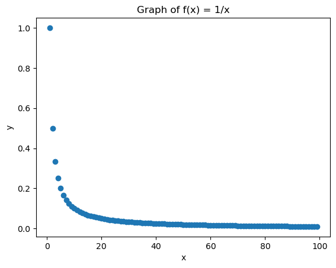

```python
e = 0.01

x_list = []
y_list = []

print(x_list)

x = 1
while 1/x > e:
    x_list.append(x)
    y_list.append(1/x)
    x = x + 1

plt.scatter(x= x_list, y = y_list)
plt.title("Graph of f(x) = 1/x")
plt.xlabel("x")
plt.ylabel("y")
```

***Example***: Finding candidates with a cutoff

```python
# This code loops over the list of players
# and stops once 2 tennis players are found


list_sports = ["tennis","golf","golf","tennis","golf","golf"]

candidate_list = []
num_candidates = 0

index = 0
while num_candidates < 2:
    print(index)
    if(list_sports[index] == "tennis"):
        candidate_list.append(index)
        num_candidates = num_candidates + 1
    index = index + 1

print(candidate_list)
```

```
0
1
2
3
[0, 3]
```

### Functions

A **function** is ...

- a **block of reusable** code to perform a a specific task
- Functions avoid repetition
- As our code grows larger, functions make it more manageable

"Built-in" functions are those from Python libraries, e.g.

`print()`, `type()`, `round()`,`abs()`, `len()`

- The "arguments" are the values of the inputs
- The "return" is the output

```python
# Argument:   "Hello"
# Return:     Showing the message on screen

print("Hello")
```

```
Hello
```

```python
# Argument:  3.14
# Return:    The type of object, e.g. int, str, boolean, float, etc.

type(3.14)
```

```
float
```

```python
# First Argument:   np.pi     (a numeric value)
# Second Argument:  6         (the number of decimals)
# Return:  Round the first argument, given the number of decimals in the second argument

round(np.pi,  6)
```

```
3.141593
```

```python
# Argument: -4
# Return:   The absolute value

abs(-4)
```

```
4
```

```python
list_fruits = ["Apple","Orange","Pear"]

# Argument: list_fruists
# Return:   The number of elements in the list

len(list_fruits)
```

```
3
```

Enter arguments by assigning parameters

```python
vec_x = np.random.chisquare(df = 2, size = 20)
vec_y = np.random.normal(loc = 2, scale = 5, size = 20)
vec_z = np.random.uniform(low = -2, high =2, size = 50)
```

You can write your own functions:

```
#---- DEFINE
    def my_function(parameter):
        body
        return expression

    #---- RUN
    my_function(parameter = argument)

    #---- RUN
    my_function(argument)
```

***Example***

Calculate $V=P\left(1+{\frac {r}{n}}\right)^{nt}$

```python
# We are going to define a function "fn_compute_value"
# You can choose any name
# Using prefixes like "fn_" can help you remember this is a "function" object
# The parameters are

def fn_compute_value(P, r, n, t):
    V = P * (1 + r/n) ** (n * t)
    return V
```

```python
# You can know compute the formula with different values

V1 = fn_compute_value(P = 1000, r = 0.01, n = 20, t=10)
V2 = fn_compute_value(P = 10, r = 0.01, n = 20, t=10)

print(V1)
print(V2)
```

```
1105.1432983541217
11.051432983541218
```

***Example***

Write a function that calculates $f(x) = x^2 + 2x + 1$.

```python
def compute_function(x):
    f = x ** 2 + 2 * x + 1
    return f

compute_function(1)
```

```
4
```

***Example***

Write a function

- with a parameter "numeric_grade"
- Inside the function write an if/else statement for grade $\ge 55$.
- If it's true, then assign "status = pass"
- If it's false, then assign "status = fail"
- Return the value of "status"

```python
def numeric_grade(grade):
    if grade >= 55:
        status = "pass"
    else:
        status = "fail"
    return status

print(numeric_grade(100))
```

```
pass
```

***Example***

Write a function

- Write a function with parameters "first_name", "laste_name", "car_model"
- Return a message saying:

"Dear customer {first_name} {last_name}, your car model {car_model} is ready"

```python
def message(first_name, last_name, car_model):
    return f"Dear customer {first_name} {last_name}, your car model {car_model} is ready."

message("Jiuru", "Lyu", "Tesla")
```

```
'Dear customer Jiuru Lyu, your car model Tesla is ready.'
```

***Lambda Functions***

"Lambda Functions" are defined in one line:

```
my_function = lambda parameters: expression
```

***Example*** Calculate $x + y + z$

```python
# (a) Define function
fn_sum = lambda x,y,z: x + y + z

# (b) Run function
fn_sum(1,2,3)
```

```
6
```

***Example***

Calculate $V=P\left(1+{\frac {r}{n}}\right)^{nt}$

```python
fn_compute_value =  lambda P,r,n,t: P*(1 + r/n)**(n*t)
```

```python
V1 = fn_compute_value(P = 1000, r = 0.01, n = 20, t=10)
V2 = fn_compute_value(P = 10, r = 0.01, n = 20, t=10)

print(V1)
print(V2)
```

```
1105.1432983541217
11.051432983541218
```

***Example***

Boleean + Functions:

- Write a function called "fn_iseligible_vote"
- This functions returns a boolean value that checks whether age $\ge$ 18

```python
fn_iseligible_vote = lambda age: (age >= 18)

print(fn_iseligible_vote(19))
```

```
True
```

***Example***

Looping + Functions:

- Create list_ages = [18,29,15,32,6]
- Write a loop that checks whether above ages are eligible to vote
- Use the above function

```python
list_ages = [18, 29, 15, 32, 6]
list_eligible = []

for age in list_ages:
    list_eligible.append(fn_iseligible_vote(age))

print(list_eligible)
```

```
[True, True, False, True, False]
```

***Functions for Visualization***

Returning a value is not always necesary, you can write:

```
#---- DEFINE
    def my_function(parameter):
        body
```

***Example***

A customized plot

- You can use functions to store your favorite aesthetic

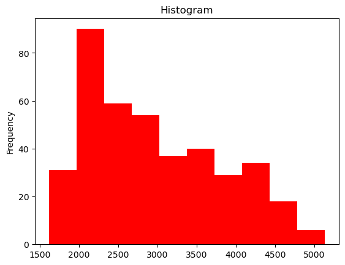

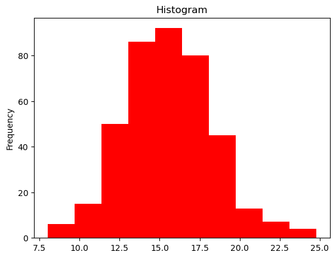

```python
def red_histogram(vec_x,title):
    plt.hist(x = vec_x, color = "red")
    plt.title(title)
    plt.ylabel("Frequency")
    plt.show()

red_histogram(vec_x = carfeatures["weight"], title = "Histogram")
red_histogram(vec_x = carfeatures["acceleration"], title = "Histogram")
```

***Example***

Create a function that computes a red scatter plot that takes $y$ and $x$ inputs

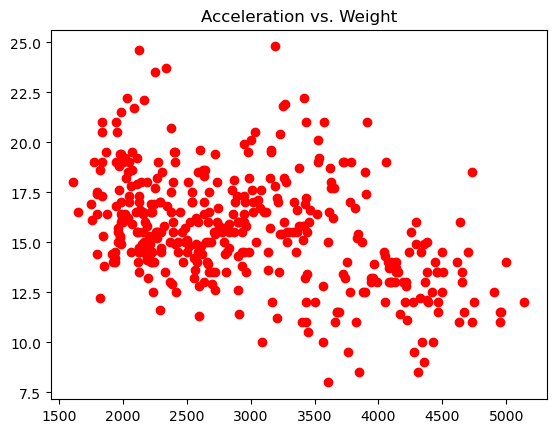

```python
def red_scatter(vec_x, vec_y, title):
    plt.scatter(x = vec_x, y = vec_y, color = "red")
    plt.title(title)
    plt.show()

red_scatter(vec_x = carfeatures["weight"], vec_y = carfeatures["acceleration"], title = "Acceleration vs. Weight")
```

### Global and Local Variables

Most of the variables we've defined so far are "global"

- Stored in working environment
- Can be referenced in other parts of the notebook

```python
message_hello = "hello"
number3       = 3
```

```python
print(message_hello + " world")
print(number3 * 2)
```

```
hello world
6
```

Any "global" variable can be referenced inside functions

- However, this can lead to mistakes
- Preferrably, include **all** the inputs as parameters

```python
# Correct Example:
def fn_add_recommended(x,y,z):
    return(x + y + z)

print(fn_add_recommended(x = 1, y = 2, z = 5))
print(fn_add_recommended(x = 1, y = 2, z = 10))
```

```
8
13
```

```python
# Example that runs (but not recommended)
# Python will try to fill in any missing inputs
# with variables in the working environment
def fn_add_notrecommended(x,y):
    return(x + y + z)

z = 5
print(fn_add_notrecommended(x = 1, y = 2))
z = 10
print(fn_add_notrecommended(x = 1, y = 2))
```

```
8
13
```

Variables defined inside functions are "local"

- Stored "temporarily" while running
- Includes: Parameters + Intermediate variables

```python
# This is an example where we define a quadratic function
# (x,y) are both local variables of the function
#
# When we call the function, only the arguments matter.
# any intermediate value inside the function

def fn_square(x):
    y = x**2
    return(y)

x = 0
y = 1
print(fn_square(x = 10))
```

```
100
```

Local variables are **not** stored in the working environment

```python
x = 5
y = 4

print("Example 1:")
print(fn_square(x = 10))
print(x)
print(y)

print("Example 2:")
print(fn_square(x = 20))
print(x)
print(y)
```

```
Example 1:
100
5
4
Example 2:
400
5
4
```

To permanently modify a variable, use the "global" command

```python
def modify_x():
    global x
    x = x + 5

x = 1
# Now, running the function wil permanently increase x by 5.
modify_x()
print(x)
```

```
6
```

***Example***

- What happens if we run "modify_x" twice?
- What happens if we add "global y" inside "fn_square"?

```python
x = 1
modify_x()
modify_x()
print(x)

def fn_square(x):
    global y
    y = x**2
    return(y)

fn_square(x)
```

```
11
```

```
121
```

### Dictionaries

A dictionary is another way to store data.

- Defined with curly brackets "{...}"
- Different fields are separated by a comma
- Assign values to a field with a colon ":"

```python
# This is an example of a pandas data frame created from a dictionary
# This example illustrates the basic syntax of a dictionary

car_dictionary = {"car_model": ["Ferrari","Tesla","BMW"],
                  "year":      ["2018","2023","2022"] }

pd.DataFrame(car_dictionary)
```

|  | car_model | year |
| --- | --- | --- |
| 0 | Ferrari | 2018 |
| 1 | Tesla | 2023 |
| 2 | BMW | 2022 |

## NumPy

### NumPy Numbers and Functions

```python
# Examples of NumPy numbers

np.pi
```

```
3.141592653589793
```

The following code are using NumPy functions of the following mathematical expressions: $$ \ln{x},\ e^x,\ \sin{x},\ \cos{x},\ \sqrt{x}. $$

```python
print(np.log(1))
print(np.exp(1))
print(np.sin(1))
print(np.cos(1))
print(np.sqrt(1))
```

```
0.0
2.718281828459045
0.8414709848078965
0.5403023058681398
1.0
```

***Exercise***

- Create a new variable, $x = 5$
- Compute $\pi x^2$
- Compute $ \frac{1}{\sqrt{2\pi}}e^{-x^2} $

```python
x = 5

print(np.pi * x**2)
print(1 / np.sqrt(2 * np.pi) * np.exp((-x ** 2)))
```

```
78.53981633974483
5.540487995575833e-12
```

### Vector Arrays

The following code creates an array from a list for the following vectors: $$ a = \left(\begin{matrix}1\\2\\3\end{matrix}\right), b = \left(\begin{matrix}0\\1\\0\end{matrix}\right), c = \left(\begin{matrix}10\\100\\1000\\2000\\5000\end{matrix}\right) $$

```python
vec_a  = np.array([1,2,3])
vec_b  = np.array([0,1,0])
vec_c  = np.array([10,100,1000,2000,5000])
```

***Exercise***

Create an array for vector $d = \left(\begin{matrix}4\\2\end{matrix}\right)$

```python
vec_d = np.array([4, 2])
```

Remember, arrays are like lists, starting their numbering at zero. We can extract values from arrays using `[index]`.

```python
print(vec_a[0])
print(vec_a[2])
```

```
1
3
```

We can use basic operators to operate with a single array and a scalar. For example, $$ a + 2 = \begin{pmatrix} a_1 + 2 \\ a_2 + 2 \\ a_3 + 2 \end{pmatrix} $$

```python
print(vec_a * 2)
print(vec_a / 2)
print(vec_a + 2)
print(vec_a ** 2)
```

```
[2 4 6]
[0.5 1.  1.5]
[3 4 5]
[1 4 9]
```

When we are operating with two arrays, we are doing element-by-element operations. $$ a + b = \begin{pmatrix} a_1 \\ a_2 \\ a_3 \end{pmatrix} + \begin{pmatrix} b_1 \\ b_2 \\ b_3 \end{pmatrix} = \begin{pmatrix} a_1 + b_1 \\ a_2 + b_2 \\ a_3 + b_3 \end{pmatrix}$$

$$ a * b = \begin{pmatrix} a_1 * b_1 \\ a_2 * b_2 \\ a_3 * b_3 \end{pmatrix}$$

***Note***: When doing element-by-element operations, make sure the arrays have the same size.

```python
print(vec_a + vec_b)
print(vec_a * vec_b)
print(vec_a - vec_b)
print(vec_a / vec_b)
```

```
[1 3 3]
[0 2 0]
[1 1 3]
[inf  2. inf]
```

We can get a statistical summary of an array using the following code

```python
print(np.mean(vec_a))
print(np.std(vec_a))
print(np.min(vec_a))
print(np.median(vec_a))
print(np.max(vec_a))
```

```
2.0
0.816496580927726
1
2.0
3
```

### *(Optional) Matrix Operations*

```python
X = np.array([[1,2,3],[4,5,6],[0,8,9]])
print(X)
```

```
[[1 2 3]
 [4 5 6]
 [0 8 9]]
```

We can use `np.column_stack()` to create a matrix by stacking different columns.

```python
Y =  np.column_stack([[1,0,1],[0,1,0]])
print(Y)
```

```
[[1 0]
 [0 1]
 [1 0]]
```

We can use `np.matrix.transpose()` to calculate the transpose of a matrix.

```python
np.matrix.transpose(Y)
```

```
array([[1, 0, 1],
       [0, 1, 0]])
```

We use `np.matmul()` to do matrix multiplications.

***Note***: Remember to check the dimensions of two matrices before doing the multiplication.

```python
np.matmul(X,Y)
```

```
array([[ 4,  2],
       [10,  5],
       [ 9,  8]])
```

We use `np.linalg.inv()` to calculate the inverse of a matrix.

```python
X_inv = np.linalg.inv(X)
print(X_inv)
```

```
[[-0.14285714  0.28571429 -0.14285714]
 [-1.71428571  0.42857143  0.28571429]
 [ 1.52380952 -0.38095238 -0.14285714]]
```

### Random Numbers

Why randomness?

- Simulate different scenarios: high risk or low risk
- Study properties of a complex system and/or estimator
- In medicine, randomly assign subjects to treatment or control

To create a vector of random variables, we can use `np.random.normal()`. More functions to generate random variables will be discussed in section 5.1.

```python
randomvar_a = np.random.normal(loc=0, scale=1, size=10)
print(randomvar_a)
```

```
[ 0.04929356  0.29161093 -2.19586755  0.52144867 -2.07762544  0.04775888
  0.32964566  1.48870342 -0.35287619  1.90266298]
```

Random numbers different every time we run the code. To avoid this problem, we need to use the function `np.random.seet()`.

```python
# No matter how many times we run this code chunk,
# The result will always be the same

np.random.seed(12345)

random_var_b = np.random.normal(loc=0, scale=1, size=10)
print(random_var_b)
```

```
[-0.20470766  0.47894334 -0.51943872 -0.5557303   1.96578057  1.39340583
  0.09290788  0.28174615  0.76902257  1.24643474]
```

The visualize random numbers, we could use histograms.

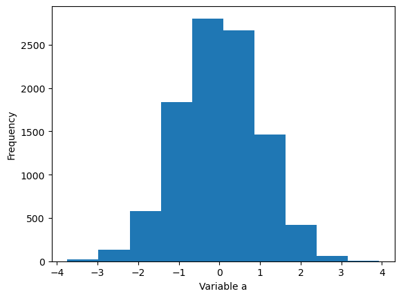

```python
randomvar_x = np.random.normal(loc=0, scale=1, size=10000)

plt.hist(x = randomvar_x)
plt.xlabel("Variable a")
plt.ylabel("Frequency")
```

### NaN (Not a Number)

We can create two arrays with and without `NaNs`.

Note: The `np.array()` function converts a list to an array

```python
vec_without_nans = np.array([1, 1, 1])
vec_with_nans = np.array([np.nan, 4, 5])
```

```python
print(vec_without_nans * vec_with_nans)
print(vec_without_nans / vec_with_nans)
print(vec_without_nans + vec_with_nans)
print(vec_without_nans - vec_with_nans)
```

```
[nan  4.  5.]
[ nan 0.25 0.2 ]
[nan  5.  6.]
[nan -3. -4.]
```

Similarly, some summary statistics will not work if there are `NaNs`.

For example The `np.mean()` doesn't work if the mean includes `NaNs`

```python
print(np.mean(vec_with_nans))
```

```
nan
```

However, some commands ignore the `NaNs`.

For example, The `np.nanmean()` computes the mean over the numeric observations.

```python
print(np.nanmean(vec_with_nans))
```

```
4.5
```

However, pandas statistical summary always ignores `NaNs`.

```python
dataset = pd.DataFrame([])
dataset["x"] = vec_with_nans
dataset["x"].mean()
```

```
4.5
```

## Data Visualization

### Matplolib Basics

We use the following code to create a scatter plot based on a data frame.

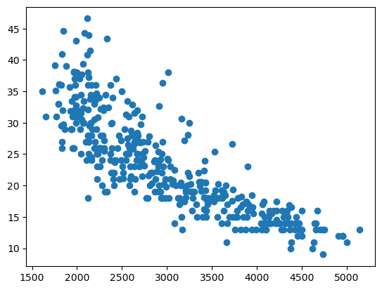

```python
plt.scatter(x = carfeatures['weight'], y = carfeatures['mpg'])
plt.show()
```

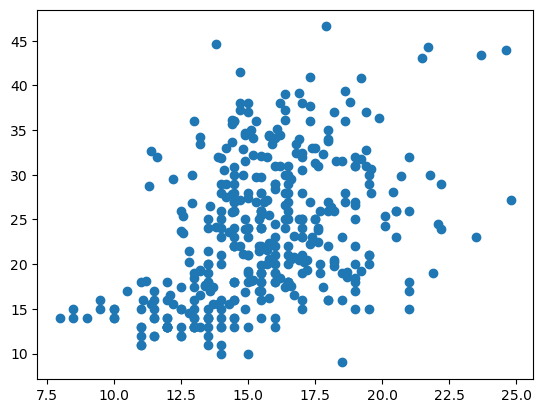

```python
# Another example
plt.scatter(x = carfeatures['acceleration'], y = carfeatures['mpg'])
plt.show()
```

Despite visualizing data frames, we can also visualize lists

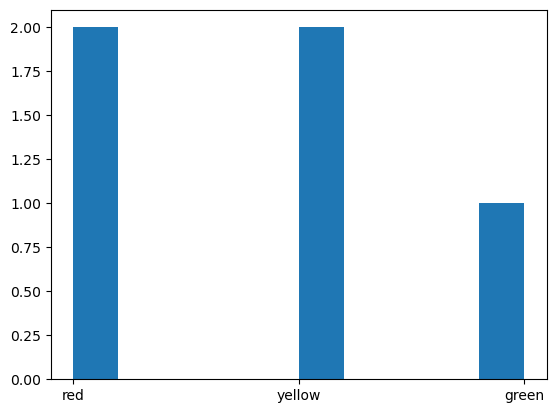

```python
# Recall the list_colors we defined in section 1.

plt.hist(x = list_colors)
```

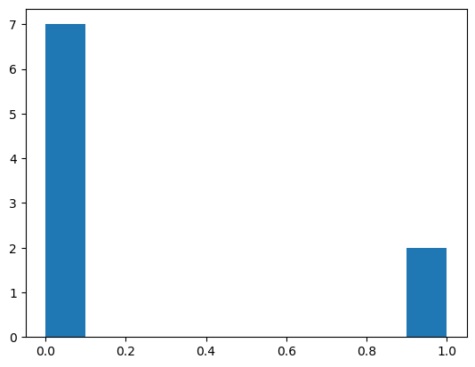

```python
# Another example

myChoice = [0, 1, 0, 0, 0, 1, 0, 0, 0]
plt.hist(myChoice)
```

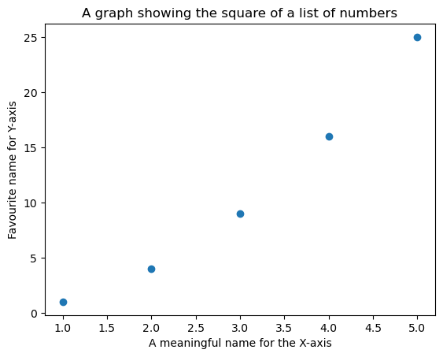

```python
# Scatter plots

plt.scatter(x = list_numbers, y = list_numbers_sqr)
plt.xlabel("A meaningful name for the X-axis")
plt.ylabel("Favourite name for Y-axis")
plt.title("A graph showing the square of a list of numbers")
plt.show()
```

***Exercise***

Create a list with numbers, and then create your own scatter plot

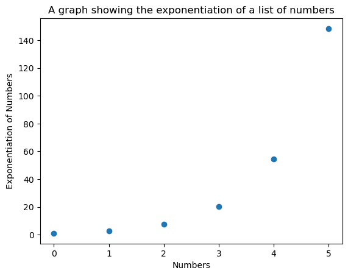

```python
e = math.e
xList = [0, 1, 2, 3, 4, 5]
yList = [e**0, e**1, e**2, e**3, e**4, e**5]

plt.scatter(x = xList, y = yList)
plt.xlabel("Numbers")
plt.ylabel("Exponentiation of Numbers")
plt.title("A graph showing the exponentiation of a list of numbers")
plt.show()
```

### Subplots

We can create multiple plots in a row, using subplots

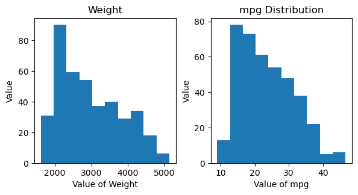

```python
#------------------------ Setting up subplots----------------------------------#
# Create a plot with 1 row, 2 columns
# You will create a list of subfigures "list_subfig"
# You can choose whichever name you like
# The option "figsize" indicates the (width,height) of the graph
fig, list_subfig = plt.subplots(1, 2,figsize = (6,3))

# The tight layout option ensures that the axes are not overlapping
plt.tight_layout()

# First Figure
list_subfig[0].hist(x = carfeatures["weight"])
list_subfig[0].set_title("Weight")
list_subfig[0].set_xlabel("Value of Weight")
list_subfig[0].set_ylabel("Value")

# Second Figure
list_subfig[1].hist(x = carfeatures["mpg"])
list_subfig[1].set_title("mpg Distribution")
list_subfig[1].set_xlabel("Value of mpg")
list_subfig[1].set_ylabel("Value")

# Note:
# Use the set_title() function for the title of subfigures
# Similarly, use "set_xlabel()" and "set_ylabel()"
```

## Pandas

### Read Data Sets

We can import .csv files

```python
carfeatures = pd.read_csv("data/features.csv")
```

We can also import other types of files, such as stata (.dta) files and Excel (.xlsx).

```python
carfeatures_dta = pd.read_stata("data/features.dta")
carfeatures_xlsx = pd.read_excel("data/features.xlsx")
```

### Write Files

We use to following codes to write files:

```python
carfeatures.to_csv("data/features_stored.csv")
carfeatures_dta.to_stata("data/features_stored.dta")
carfeatures_xlsx.to_excel("data/features_stored.xlsx")
```

### Data Frame Basics

We can enter the nae of a data frame to take a glimpse at it

```python
carfeatures
```

|  | mpg | cylinders | displacement | horsepower | weight | acceleration | vehicle id |
| --- | --- | --- | --- | --- | --- | --- | --- |
| 0 | 18.0 | 8 | 307 | 130 | 3504 | 12.0 | C-1689780 |
| 1 | 15.0 | 8 | 350 | 165 | 3693 | 11.5 | B-1689791 |
| 2 | 18.0 | 8 | 318 | 150 | 3436 | 11.0 | P-1689802 |
| 3 | 16.0 | 8 | 304 | 150 | 3433 | 12.0 | A-1689813 |
| 4 | 17.0 | 8 | 302 | 140 | 3449 | 10.5 | F-1689824 |
| ... | ... | ... | ... | ... | ... | ... | ... |
| 393 | 27.0 | 4 | 140 | 86 | 2790 | 15.6 | F-1694103 |
| 394 | 44.0 | 4 | 97 | 52 | 2130 | 24.6 | V-1694114 |
| 395 | 32.0 | 4 | 135 | 84 | 2295 | 11.6 | D-1694125 |
| 396 | 28.0 | 4 | 120 | 79 | 2625 | 18.6 | F-1694136 |
| 397 | 31.0 | 4 | 119 | 82 | 2720 | 19.4 | C-1694147 |

398 rows × 7 columns

If we want output data for a single column, we use `[...]`

```python
carfeatures["cylinders"]
```

```
0      8
1      8
2      8
3      8
4      8
      ..
393    4
394    4
395    4
396    4
397    4
Name: cylinders, Length: 398, dtype: int64
```

```python
# Antoher example

carfeatures["mpg"]
```

```
0      18.0
1      15.0
2      18.0
3      16.0
4      17.0
       ...
393    27.0
394    44.0
395    32.0
396    28.0
397    31.0
Name: mpg, Length: 398, dtype: float64
```

We can create a frequency table using the following syntax

```
pd.crosstab(indenx = df["column"], columns = "Name")
```

```python
pd.crosstab(index = carfeatures['cylinders'],columns = "How many cars have (x) cylinders?")
```

| col_0 cylinders | How many cars have (x) cylinders? |
| --- | --- |
| 3 | 4 |
| 4 | 204 |
| 5 | 3 |
| 6 | 84 |
| 8 | 103 |

```python
# Another example

pd.crosstab(index = carfeatures['mpg'], columns = "Hello")
```

| col_0 mpg | Hello |
| --- | --- |
| 9.0 | 1 |
| 10.0 | 2 |
| 11.0 | 4 |
| 12.0 | 6 |
| 13.0 | 20 |
| ... | ... |
| 43.4 | 1 |
| 44.0 | 1 |
| 44.3 | 1 |
| 44.6 | 1 |
| 46.6 | 1 |

129 rows × 1 columns

We use the following syntax to compute basic summary statistics for all variables in a data set

```python
carfeatures.describe()
```

|  | mpg | cylinders | displacement | weight | acceleration |
| --- | --- | --- | --- | --- | --- |
| count | 398.000000 | 398.000000 | 398.000000 | 398.000000 | 398.000000 |
| mean | 23.514573 | 5.454774 | 193.427136 | 2970.424623 | 15.568090 |
| std | 7.815984 | 1.701004 | 104.268683 | 846.841774 | 2.757689 |
| min | 9.000000 | 3.000000 | 68.000000 | 1613.000000 | 8.000000 |
| 25% | 17.500000 | 4.000000 | 104.250000 | 2223.750000 | 13.825000 |
| 50% | 23.000000 | 4.000000 | 148.500000 | 2803.500000 | 15.500000 |
| 75% | 29.000000 | 8.000000 | 262.000000 | 3608.000000 | 17.175000 |
| max | 46.600000 | 8.000000 | 455.000000 | 5140.000000 | 24.800000 |

### Operations Over Data Frames

Create an empty data frame

```python
data  = pd.DataFrame([])
```

Add variables

```python
# The following are lists with values for different individuals
# "age" is the number of years
# "num_underage_siblings" is the total number of underage siblings
# "num_adult_siblings" is the total number of adult siblings

data["age"]                   = [18,29,15,32,6]
data["num_underage_siblings"] = [0,0,1,1,0]
data["num_adult_siblings"]    = [1,0,0,1,0]
```

Define functions

```python
fn_iseligible_vote = lambda age: age >= 18
fn_istwenties      = lambda age: (age >= 20) & (age < 30)
fn_sum             = lambda x,y: x + y

def fn_agebracket(age):
    if (age >= 18):
        status = "Adult"
    elif (age >= 10) & (age < 18):
        status = "Adolescent"
    else:
        status = "Child"
    return(status)
```

Applying functions with one argument:

```
apply(myfunction)
```

- Takes a dataframe series (a column vector) as an input
- Computes function separately for each individual

```python
# The fucntion "apply" will extract each element and return the function value
# It is similar to running a "for-loop" over each element

data["can_vote"]    = data["age"].apply(fn_iseligible_vote)
data["in_twenties"] = data["age"].apply(fn_istwenties)
data["age_bracket"] = data["age"].apply(fn_agebracket)


# NOTE: The following code also works:
# data["can_vote"]    = data["age"].apply(lambda age: age >= 18)
# data["in_twenties"] = data["age"].apply(lambda age: (age >= 20) & (age < 30))

display(data)
```

|  | age | num_underage_siblings | num_adult_siblings | can_vote | in_twenties | age_bracket |
| --- | --- | --- | --- | --- | --- | --- |
| 0 | 18 | 0 | 1 | True | False | Adult |
| 1 | 29 | 0 | 0 | True | True | Adult |
| 2 | 15 | 1 | 0 | False | False | Adolescent |
| 3 | 32 | 1 | 1 | True | False | Adult |
| 4 | 6 | 0 | 0 | False | False | Child |

Mapping functions with one or more arguments

```
list(map(myfunction, list1,list2, ....))
```

```python
# Repeat the above example with map
# We use list() to convert the output to a list
# The first argument of map() is a function
# The following arguments are the subarguments of the function

data["can_vote"] = list(map(fn_iseligible_vote, data["age"]))
```

```python
# In this example, there are more than two arguments

data["num_siblings"] = list(map(fn_sum,data["num_underage_siblings"],data["num_adult_siblings"]))
```

Recommended!

- Arguments can be split into multiple lines!
- Start a separate line after a comma
- Experts recommend each line has 80 characters or less

```python
data["num_siblings"] = list(map(fn_sum,
                                data["num_underage_siblings"],
                                data["num_adult_siblings"]))
```

***Example***

- Write a function checking whether num_siblings $\ge$ 1
- Add a variable to the dataset called "has_siblings"
- Assign True/False to this variable using "apply()"

```python
check_num_siblings = lambda x: x >= 1

data["has_siblings"] = data["num_siblings"].apply(check_num_siblings)

display(data)
```

|  | age | num_underage_siblings | num_adult_siblings | can_vote | in_twenties | age_bracket | num_siblings | has_siblings |
| --- | --- | --- | --- | --- | --- | --- | --- | --- |
| 0 | 18 | 0 | 1 | True | False | Adult | 1 | True |
| 1 | 29 | 0 | 0 | True | True | Adult | 0 | False |
| 2 | 15 | 1 | 0 | False | False | Adolescent | 1 | True |
| 3 | 32 | 1 | 1 | True | False | Adult | 2 | True |
| 4 | 6 | 0 | 0 | False | False | Child | 0 | False |

***Example***

- Read the car dataset "data/features.csv"
- Create a function that tests whether mpg $\ge$ 29
- Add a variable "mpg_above_29" which is True/False if mpg $\ge$ 29
- Store the new dataset to "data/features_clean.csv"

```python
carfeatures["mpg_above_29"] = list(map(lambda x: x >= 29, carfeatures["mpg"]))

carfeatures.to_csv("data/features_clean.csv")
```

***Example***

- Map can also be applied to simple lists!
- Create a lambda function with arguments {fruit,color}.
- The function returns the string

" A {fruit} is {color}"

- Create the following two lists:

`list_fruits = ["banana","strawberry","kiwi"]`

`list_colors = ["yellow","red","green"]`

```python
fruit_color = lambda fruit, color: f"A {fruit} is {color}."

list_fruits  = ["banana","strawberry","kiwi"]
list_colors  = ["yellow","red","green"]

list(map(fruit_color, list_fruits, list_colors))
```

```
['A banana is yellow.', 'A strawberry is red.', 'A kiwi is green.']
```

*(Optional)* External Scripts

".ipynb" files ...

- Markdown + python code
- Great for interactive output!

".py" files ...

- Python (only) script
- Used for specific tasks
- Why? Split code into smaller, more manageable files

```python
#------------------------------------------------------------------------------#
# The "%run -i" command executes a Python script that is
# in the subfolder "programs/"
#
#      Breaking down the command:
#      (a) The percentage sign "%" is associated with "magic commands"
#          which are special functions used in iPython notebooks.
#      (b) The suboption "-i" ensures that the program can use any variables
#          defined in the curent working environment (in case it's necessary)
#------------------------------------------------------------------------------#

%run -i "scripts/example_functions.py"

x = 1
print(fn_quadratic(1))
print(fn_quadratic(5))
```

```
1
25
```

```python
# When we run this program
# the value of alpha will be overwritten

alpha = 1
print(alpha)

%run -i "scripts/example_variables.py"
print(alpha)
```

```
1
5
```

### Sub-Setting Data

The display() command will show the first 5 rows and the last five rows

```python
display(carfeatures)
```

|  | mpg | cylinders | displacement | horsepower | weight | acceleration | vehicle id | mpg_above_29 |
| --- | --- | --- | --- | --- | --- | --- | --- | --- |
| 0 | 18.0 | 8 | 307 | 130 | 3504 | 12.0 | C-1689780 | False |
| 1 | 15.0 | 8 | 350 | 165 | 3693 | 11.5 | B-1689791 | False |
| 2 | 18.0 | 8 | 318 | 150 | 3436 | 11.0 | P-1689802 | False |
| 3 | 16.0 | 8 | 304 | 150 | 3433 | 12.0 | A-1689813 | False |
| 4 | 17.0 | 8 | 302 | 140 | 3449 | 10.5 | F-1689824 | False |
| ... | ... | ... | ... | ... | ... | ... | ... | ... |
| 393 | 27.0 | 4 | 140 | 86 | 2790 | 15.6 | F-1694103 | False |
| 394 | 44.0 | 4 | 97 | 52 | 2130 | 24.6 | V-1694114 | True |
| 395 | 32.0 | 4 | 135 | 84 | 2295 | 11.6 | D-1694125 | True |
| 396 | 28.0 | 4 | 120 | 79 | 2625 | 18.6 | F-1694136 | False |
| 397 | 31.0 | 4 | 119 | 82 | 2720 | 19.4 | C-1694147 | True |

398 rows × 8 columns

Extract column names

```python
# Write the name of the dataset and use a period "." to extract
# the attribute "columns" and the subttribute "values"

car_colnames = carfeatures.columns.values
print(car_colnames)
```

```
['mpg' 'cylinders' 'displacement' 'horsepower' 'weight' 'acceleration'
 'vehicle id' 'mpg_above_29']
```

Subset columns:

```
data[list_names]
```

```python
# To subset multiple columns write the name of the datasets
# and enter a list in square brackets next to the name

list_subsetcols     = ["weight","mpg"]
subcols_carfeatures = carfeatures[list_subsetcols]
display(subcols_carfeatures)

# Or we can simply include the list directly inside square brackets
display(carfeatures[["weight","mpg"]])
```

|  | weight | mpg |
| --- | --- | --- |
| 0 | 3504 | 18.0 |
| 1 | 3693 | 15.0 |
| 2 | 3436 | 18.0 |
| 3 | 3433 | 16.0 |
| 4 | 3449 | 17.0 |
| ... | ... | ... |
| 393 | 2790 | 27.0 |
| 394 | 2130 | 44.0 |
| 395 | 2295 | 32.0 |
| 396 | 2625 | 28.0 |
| 397 | 2720 | 31.0 |

398 rows × 2 columns

|  | weight | mpg |
| --- | --- | --- |
| 0 | 3504 | 18.0 |
| 1 | 3693 | 15.0 |
| 2 | 3436 | 18.0 |
| 3 | 3433 | 16.0 |
| 4 | 3449 | 17.0 |
| ... | ... | ... |
| 393 | 2790 | 27.0 |
| 394 | 2130 | 44.0 |
| 395 | 2295 | 32.0 |
| 396 | 2625 | 28.0 |
| 397 | 2720 | 31.0 |

398 rows × 2 columns

***Example*** Extract the weight and acceleration variables

```python
display(carfeatures[["weight", "acceleration"]])
```

|  | weight | acceleration |
| --- | --- | --- |
| 0 | 3504 | 12.0 |
| 1 | 3693 | 11.5 |
| 2 | 3436 | 11.0 |
| 3 | 3433 | 12.0 |
| 4 | 3449 | 10.5 |
| ... | ... | ... |
| 393 | 2790 | 15.6 |
| 394 | 2130 | 24.6 |
| 395 | 2295 | 11.6 |
| 396 | 2625 | 18.6 |
| 397 | 2720 | 19.4 |

398 rows × 2 columns

Sort by column

```python
carsorted = carfeatures.sort_values(by = "mpg", ascending = False) # False: descending order
display(carsorted)
```

|  | mpg | cylinders | displacement | horsepower | weight | acceleration | vehicle id | mpg_above_29 |
| --- | --- | --- | --- | --- | --- | --- | --- | --- |
| 322 | 46.6 | 4 | 86 | 65 | 2110 | 17.9 | M-1693322 | True |
| 329 | 44.6 | 4 | 91 | 67 | 1850 | 13.8 | H-1693399 | True |
| 325 | 44.3 | 4 | 90 | 48 | 2085 | 21.7 | V-1693355 | True |
| 394 | 44.0 | 4 | 97 | 52 | 2130 | 24.6 | V-1694114 | True |
| 326 | 43.4 | 4 | 90 | 48 | 2335 | 23.7 | V-1693366 | True |
| ... | ... | ... | ... | ... | ... | ... | ... | ... |
| 103 | 11.0 | 8 | 400 | 150 | 4997 | 14.0 | C-1690913 | False |
| 67 | 11.0 | 8 | 429 | 208 | 4633 | 11.0 | M-1690517 | False |
| 25 | 10.0 | 8 | 360 | 215 | 4615 | 14.0 | F-1690055 | False |
| 26 | 10.0 | 8 | 307 | 200 | 4376 | 15.0 | C-1690066 | False |
| 28 | 9.0 | 8 | 304 | 193 | 4732 | 18.5 | H-1690088 | False |

398 rows × 8 columns

Subset row(s)

`data.iloc[ row_int , : ]` $\quad$ or

`data.iloc[ list_rows, : ]`

```python
# The following command extracts all columns for row zero
# Remember that numbering starts at zero in Python
# In this case we will show the car with the highest "mpg" value

display(carsorted.iloc[0,:])
display(carsorted.iloc[[0,1,2],:])
```

```
mpg                  46.6
cylinders               4
displacement           86
horsepower             65
weight               2110
acceleration         17.9
vehicle id      M-1693322
mpg_above_29         True
Name: 322, dtype: object
```

|  | mpg | cylinders | displacement | horsepower | weight | acceleration | vehicle id | mpg_above_29 |
| --- | --- | --- | --- | --- | --- | --- | --- | --- |
| 322 | 46.6 | 4 | 86 | 65 | 2110 | 17.9 | M-1693322 | True |
| 329 | 44.6 | 4 | 91 | 67 | 1850 | 13.8 | H-1693399 | True |
| 325 | 44.3 | 4 | 90 | 48 | 2085 | 21.7 | V-1693355 | True |

Subset block of rows

`data.iloc[ lower:upper , : ]`

```python
# Extract rows 0 to 5
display(carfeatures.iloc[0:5,:])

# Extract rows 8 onwards
display(carfeatures.iloc[8:, : ])

# Note: We can leave the numbers to the left and right of ":" blank
# in order to select all values before or after, respectively.
```

|  | mpg | cylinders | displacement | horsepower | weight | acceleration | vehicle id | mpg_above_29 |
| --- | --- | --- | --- | --- | --- | --- | --- | --- |
| 0 | 18.0 | 8 | 307 | 130 | 3504 | 12.0 | C-1689780 | False |
| 1 | 15.0 | 8 | 350 | 165 | 3693 | 11.5 | B-1689791 | False |
| 2 | 18.0 | 8 | 318 | 150 | 3436 | 11.0 | P-1689802 | False |
| 3 | 16.0 | 8 | 304 | 150 | 3433 | 12.0 | A-1689813 | False |
| 4 | 17.0 | 8 | 302 | 140 | 3449 | 10.5 | F-1689824 | False |

|  | mpg | cylinders | displacement | horsepower | weight | acceleration | vehicle id | mpg_above_29 |
| --- | --- | --- | --- | --- | --- | --- | --- | --- |
| 8 | 14.0 | 8 | 455 | 225 | 4425 | 10.0 | P-1689868 | False |
| 9 | 15.0 | 8 | 390 | 190 | 3850 | 8.5 | A-1689879 | False |
| 10 | 15.0 | 8 | 383 | 170 | 3563 | 10.0 | D-1689890 | False |
| 11 | 14.0 | 8 | 340 | 160 | 3609 | 8.0 | P-1689901 | False |
| 12 | 15.0 | 8 | 400 | 150 | 3761 | 9.5 | C-1689912 | False |
| ... | ... | ... | ... | ... | ... | ... | ... | ... |
| 393 | 27.0 | 4 | 140 | 86 | 2790 | 15.6 | F-1694103 | False |
| 394 | 44.0 | 4 | 97 | 52 | 2130 | 24.6 | V-1694114 | True |
| 395 | 32.0 | 4 | 135 | 84 | 2295 | 11.6 | D-1694125 | True |
| 396 | 28.0 | 4 | 120 | 79 | 2625 | 18.6 | F-1694136 | False |
| 397 | 31.0 | 4 | 119 | 82 | 2720 | 19.4 | C-1694147 | True |

390 rows × 8 columns

Similar for columns

- One column: $\quad$ `data.iloc[ : , col_integer ]`
- Multiple columns: $\quad$ `data.iloc[ : , list_cols ]`
- Row+Column: $\quad$ `data.iloc[ list_rows , list_cols ]`

***Example***

- Create a new datate called "car_ascendingmpg" which

sorts cars from lowest to highest mpg

- Subset the data of 5 cars with the lowest "mpg"

HINT: Use `sort_values(...,ascending = TRUE`)

```python
car_ascendingmpg = carfeatures.sort_values(by = "mpg", ascending = True)

display(car_ascendingmpg.iloc[:5,:])
```

|  | mpg | cylinders | displacement | horsepower | weight | acceleration | vehicle id | mpg_above_29 |
| --- | --- | --- | --- | --- | --- | --- | --- | --- |
| 28 | 9.0 | 8 | 304 | 193 | 4732 | 18.5 | H-1690088 | False |
| 25 | 10.0 | 8 | 360 | 215 | 4615 | 14.0 | F-1690055 | False |
| 26 | 10.0 | 8 | 307 | 200 | 4376 | 15.0 | C-1690066 | False |
| 103 | 11.0 | 8 | 400 | 150 | 4997 | 14.0 | C-1690913 | False |
| 124 | 11.0 | 8 | 350 | 180 | 3664 | 11.0 | O-1691144 | False |

Filter the data based on its content

```
data.query("logical expression")
```

(i) Expressions with colnames

```python
data_threshold_mpg        = carfeatures.query("mpg >= 25")
data_rangeacceleration    = carfeatures.query("(acceleration >= 10) & (acceleration < 18)")
```

(ii) Expressions with colnames + global variables (@)

```python
# You can invoke global variables into the query by using @variablename
# If you don't include @, then Python will try to look for a column with
# that name.

threshold = 25
data_varthreshold_mpg = carfeatures.query("mpg >= @threshold")
```

(iii) Expressions with colnames with spaces

```python
# Sometimes column names have spaces in them
# In this case use the "`" symbol, e.g.          `variable name`

carfeatures["new variable"] = carfeatures["mpg"]
data_spacesthreshold_mpg = carfeatures.query("`new variable` >= 25")
```

***Example***

- Subset the data with mpg $\ge$ 25 and cylinders == 8

```python
display(carfeatures.query("(mpg >= 25) & (cylinders == 8)"))

# To run it with global variables
mpg_threshold = 25
cylinders_threshold = 8
display(carfeatures.query("(mpg >= @mpg_threshold) & (cylinders == @cylinders_threshold)"))
```

|  | mpg | cylinders | displacement | horsepower | weight | acceleration | vehicle id | mpg_above_29 | new variable |
| --- | --- | --- | --- | --- | --- | --- | --- | --- | --- |
| 364 | 26.6 | 8 | 350 | 105 | 3725 | 19.0 | O-1693784 | False | 26.6 |

|  | mpg | cylinders | displacement | horsepower | weight | acceleration | vehicle id | mpg_above_29 | new variable |
| --- | --- | --- | --- | --- | --- | --- | --- | --- | --- |
| 364 | 26.6 | 8 | 350 | 105 | 3725 | 19.0 | O-1693784 | False | 26.6 |

List of unique categories

```python
# Use pd.unique() to extract a list with the unique elements in that column

list_unique_cylinders = pd.unique(carfeatures["cylinders"])
print(list_unique_cylinders)
```

```
[8 4 6 3 5]
```

Compute two overlapping plots

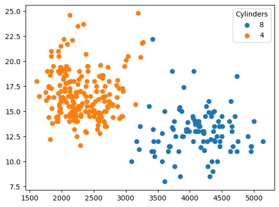

```python
# If we call plt.scatter() twice to display two plots
# To display all plots simultaneously we include plt.show() at the very end.
# The idea is that the graphs are stacked on top of each other

df_8 = carfeatures.query("cylinders == 8")
df_4 = carfeatures.query("cylinders == 4")

plt.scatter(x = df_8["weight"],y = df_8["acceleration"])
plt.scatter(x = df_4["weight"],y = df_4["acceleration"])
plt.legend(labels = ["8","4"], title  = "Cylinders")

plt.show()

# Note: If we put plt.show() in between the plots, then the results will
# be shown on separate graphs instead.
```

Compute plots by all categories

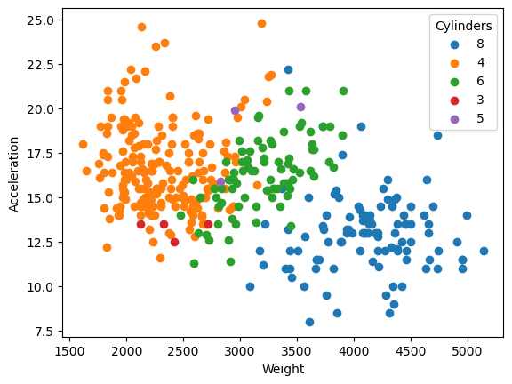

```python
# Compute number of unique categories
list_unique_cylinders = pd.unique(carfeatures["cylinders"])

# Use a for loop to plot a scatter plot between "weight" and "acceleration"
# for each category. Each plot  will have a different color

for category in list_unique_cylinders:
    df   = carfeatures.query("cylinders == @category")
    plt.scatter(x = df["weight"],y = df["acceleration"])

# Add labels and a legends
plt.xlabel("Weight")
plt.ylabel("Acceleration")
plt.legend(labels = list_unique_cylinders,
           title  = "Cylinders")
plt.show()
```

***Example***

- Compute a histogram of "mpg" by cylinder count
- Make the histograms transparent by adjusting `alpha` in

`plt.hist(x = ..., alpha = 0.5)`

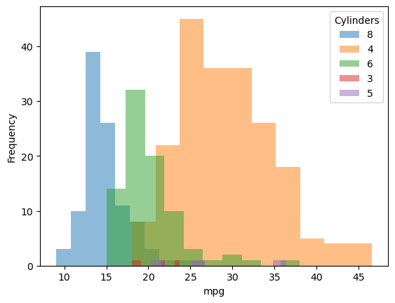

```python
list_unique_cylinders = pd.unique(carfeatures["cylinders"])

for cylinder in list_unique_cylinders:
    df = carfeatures.query("cylinders == @cylinder")
    plt.hist(x = df["mpg"], alpha = 0.5)

plt.xlabel("mpg")
plt.ylabel("Frequency")
plt.legend(labels = list_unique_cylinders, title  = "Cylinders")
plt.show()
```

### Random Assignment

Random assignment is crucial for scientific progress ...

- The basis for medical trials
- Also used in engineering, the natural sciences and  
  social sciences (economics, political science, etc.)

```python
# "list_status" is a list with "treatment/control" arms
# "prop_status" is the proportion in the treatment and control arms
# "size_dataset" is how many rows are contained

list_status  = ["Treatment","Control"]
prop_status  = [0.4,0.6]
size_dataset = len(carfeatures)
```

Random assignment

```python
# The "np.random.choice" will create a vector with the status
# We will save this to a column in "carfeatures"
# Note: (i) We can always split the arguments of a function in multiple lines
#           to make it easier to read
#       (ii)

carfeatures["status"] = np.random.choice(list_status,
                                         size = size_dataset,
                                         p = prop_status)

display(carfeatures)
```

|  | mpg | cylinders | displacement | horsepower | weight | acceleration | vehicle id | mpg_above_29 | new variable | status |
| --- | --- | --- | --- | --- | --- | --- | --- | --- | --- | --- |
| 0 | 18.0 | 8 | 307 | 130 | 3504 | 12.0 | C-1689780 | False | 18.0 | Control |
| 1 | 15.0 | 8 | 350 | 165 | 3693 | 11.5 | B-1689791 | False | 15.0 | Treatment |
| 2 | 18.0 | 8 | 318 | 150 | 3436 | 11.0 | P-1689802 | False | 18.0 | Treatment |
| 3 | 16.0 | 8 | 304 | 150 | 3433 | 12.0 | A-1689813 | False | 16.0 | Control |
| 4 | 17.0 | 8 | 302 | 140 | 3449 | 10.5 | F-1689824 | False | 17.0 | Treatment |
| ... | ... | ... | ... | ... | ... | ... | ... | ... | ... | ... |
| 393 | 27.0 | 4 | 140 | 86 | 2790 | 15.6 | F-1694103 | False | 27.0 | Treatment |
| 394 | 44.0 | 4 | 97 | 52 | 2130 | 24.6 | V-1694114 | True | 44.0 | Control |
| 395 | 32.0 | 4 | 135 | 84 | 2295 | 11.6 | D-1694125 | True | 32.0 | Control |
| 396 | 28.0 | 4 | 120 | 79 | 2625 | 18.6 | F-1694136 | False | 28.0 | Control |
| 397 | 31.0 | 4 | 119 | 82 | 2720 | 19.4 | C-1694147 | True | 31.0 | Control |

398 rows × 10 columns

Compute frequencies by status

```python
# The command "pd.crosstab" computes frequencies
# If we add the option "normalize" it will compute proportions
# Note: The default assignment is done randomly without replacement
#       which means that the proportions are approximately the same
#       (but not equal) to "prop_status"

frequency_table   = pd.crosstab(index = carfeatures["status"], columns = "Frequency")
proportions_table = pd.crosstab(index = carfeatures["status"],
                                columns = "Frequency",
                                normalize = True)

display(frequency_table)
display(proportions_table)
```

| col_0 status | Frequency |
| --- | --- |
| Control | 233 |
| Treatment | 165 |

| col_0 status | Frequency |
| --- | --- |
| Control | 0.585427 |
| Treatment | 0.414573 |

Query with string conditions

```python
# When you have queries for text variables, it's important
# to use outer ' ' single quotations
# and inner double quotations.

data_treated = carfeatures.query('status == "Treatment" ')
data_control = carfeatures.query('status == "Control" ')
```

Treated/control should be similar

- This is the key principle of random assignment
- We can check the summary statistics

```python
# The count is different because we assigned different proportions
# All other sumary statistics are approximately the same
# They are not identical because the assignment is random

display(data_treated.describe())
display(data_control.describe())
```

|  | mpg | cylinders | displacement | weight | acceleration | new variable |
| --- | --- | --- | --- | --- | --- | --- |
| count | 165.000000 | 165.000000 | 165.000000 | 165.000000 | 165.000000 | 165.000000 |
| mean | 22.605455 | 5.600000 | 203.927273 | 3060.224242 | 15.503030 | 22.605455 |
| std | 7.451144 | 1.717201 | 106.798281 | 887.013772 | 2.657925 | 7.451144 |
| min | 9.000000 | 3.000000 | 70.000000 | 1800.000000 | 9.000000 | 9.000000 |
| 25% | 17.000000 | 4.000000 | 101.000000 | 2220.000000 | 13.700000 | 17.000000 |
| 50% | 21.100000 | 6.000000 | 168.000000 | 2904.000000 | 15.500000 | 21.100000 |
| 75% | 27.500000 | 8.000000 | 302.000000 | 3725.000000 | 17.000000 | 27.500000 |
| max | 46.600000 | 8.000000 | 455.000000 | 5140.000000 | 22.200000 | 46.600000 |

|  | mpg | cylinders | displacement | weight | acceleration | new variable |
| --- | --- | --- | --- | --- | --- | --- |
| count | 233.000000 | 233.000000 | 233.000000 | 233.000000 | 233.000000 | 233.000000 |
| mean | 24.158369 | 5.351931 | 185.991416 | 2906.832618 | 15.614163 | 24.158369 |
| std | 8.017875 | 1.685565 | 102.016944 | 813.141144 | 2.830973 | 8.017875 |
| min | 10.000000 | 3.000000 | 68.000000 | 1613.000000 | 8.000000 | 10.000000 |
| 25% | 18.000000 | 4.000000 | 105.000000 | 2234.000000 | 13.900000 | 18.000000 |
| 50% | 23.500000 | 4.000000 | 140.000000 | 2720.000000 | 15.400000 | 23.500000 |
| 75% | 31.000000 | 6.000000 | 250.000000 | 3445.000000 | 17.300000 | 31.000000 |
| max | 44.600000 | 8.000000 | 455.000000 | 4997.000000 | 24.800000 | 44.600000 |

### Replacing and Recoding Values

To clean a data set, we first see the types of it.

```python
# Produces a list with the data types of each column
# Columns that say "object" have either strings or
# a mix of string and numeric values

circuits.dtypes
```

```
circuitId       int64
circuitRef     object
name           object
location       object
country        object
lat           float64
lng           float64
alt            object
url            object
dtype: object
```

From the code book, we know `alt` should be numeric data, but it is an object (text string) according to the last output.

Hence, we use `.str.isnumeric()` to check which values of `alt` is not numeric.

```python
# The ".str.isnumeric()" checks whether each row is numeric or now.
# Using the "." twice is an example of "piping"
# which refers to chaining two commands "str" and "isnumeric()"

circuits["alt"].str.isnumeric()
```

```
0      True
1      True
2      True
3      True
4      True
      ...
72     True
73     True
74     True
75    False
76    False
Name: alt, Length: 77, dtype: bool
```

To extract those rows of non-numeric values, we combine the `.str.isnumeric()` function with `.query()`.

```python
# We can reference subattributes of columns in ".query()"
# The pd.unique() function extracts unique values from a list

subset      = circuits.query("alt.str.isnumeric() == False")
list_unique = pd.unique(subset["alt"])
print(list_unique)
```

```
['\\N' '-7']
```

To clean the data set, we change the non-numeric values to numeric values.

```python
# "list_old" encodes values we want to change
# "list_new" encodes the values that will "replace" the old
list_old = ['\\N','-7']
list_new = [np.nan,-7]

# This command replaces the values of the "alt" column
circuits["alt"] = circuits["alt"].replace(list_old, list_new)

# Note: The option "inplace = True" permanently modifies the column
# circuits["alt"].replace(list_old, list_new, inplace = True)
```

***Example***

- Use `.replace()` with the "country" column
- Replace "UK" with "United Kingdom"

```python
circuits["country"] = circuits["country"].replace("UK", "United Kingdom")
```

***Example***

- Are there any non-numeric values in `lat` or `long`?
- Use `.query()` + `.str.isnumeric()`

```python
# Write your own code

# subset_lat = circuits.query("lat.str.isnumeric() == False")
# subset_long = circuits.query("lng.str.isnumeric() == False")

# ERROR: Only use .str accessor with string values! --> no string values in lat or long

circuits[["lat", "lng"]].dtypes
```

```
lat    float64
lng    float64
dtype: object
```

Sometimes, we need to recode the values. The very common one is to convert values from object to numeric (text strings will be recoded as `NaN`s after conversion).

```python
circuits["alt_numeric"] = pd.to_numeric(circuits["alt"])
print(circuits["alt_numeric"].mean())
```

```
248.1891891891892
```

In other cases, the recoding process might be more complicated.

***Example***

Recode values based on an interval

$$ \qquad x_{bin} = \begin{cases} `A' &\text{ if }\quad x_1 < x \le x_2 \\ `B' &\text{ if }\quad x_2 < x \le x_3 \end{cases} $$

```python
# bins and labels must increase monotonically
bins_x = [0, 2500, 5000]
labels_x = ["Between 0 and 2500",
            "Between 2500 and 5000"]

circuits["bins_alt"] = pd.cut(circuits["alt_numeric"],
                              bins = bins_x,
                              right = True,
                              labels = labels_x)

# Note: if we set bins_x = [float("-inf"), 2500, float("inf")]
#       then intervals are "Less than or equal to 2500" and "Above 2500"
#       float("inf") and float("-inf") represent infinity and negative infinity
#       The "right" command indicates that the right interval is
#       "less than or equal to"
```

***Example***

- Create a new variable "hemisphere"
- Encode lattitude in (-90 and 0] as "south"
- Encode lattitude in (0 and 90] as "north"

```python
bins_lat = [-90, 0, 90]
labels_lat = ["south", "north"]

circuits["hemisphere"] = pd.cut(circuits["lat"],
                                bins = bins_lat,
                                right = True,
                                labels = labels_lat)
```

### Aggregating Data

In this section, we will use the `result` data set. Let's first see its rows and data types

```python
results.dtypes
```

```
resultId             int64
raceId               int64
driverId             int64
constructorId        int64
number              object
grid                 int64
position            object
positionText        object
positionOrder        int64
points             float64
laps                 int64
time                object
milliseconds        object
fastestLap          object
rank                object
fastestLapTime      object
fastestLapSpeed     object
statusId             int64
dtype: object
```

Further, we will answer the following questions:

- How many rows does the dataset have?
- How many unique values are there for the columns

$\qquad$ "resultId"?  
$\qquad$ "raceId"?  
$\qquad$ "driverId"?

HINT: Use the "len()" and the "pd.unique()" functions

```python
print(len(results))
print(len(pd.unique(results["resultId"]))) # Primary key -- unique identifiers of the data set
print(len(pd.unique(results["raceId"])))
print(len(pd.unique(results["driverId"])))
```

```
25840
25840
1079
855
```

Splitting code into multiple lines

- Makes it easier to read
- Simply wrap the code in round parentheses "()"

```python
# The following code computes descriptive statistics for points
# Wrapping the code in parentheses "()" allows you to split it into multiple
# lines. It's considered good practice to make each line less than 80 characters
# This makes it easier to scroll up and down without going sideways.

descriptives_singleline = results["points"].describe()
descriptives_multiline = (results["points"]
                          .describe())

print(descriptives_multiline)
print(descriptives_singleline) # They are the same!
```

```
count    25840.000000
mean         1.877053
std          4.169849
min          0.000000
25%          0.000000
50%          0.000000
75%          2.000000
max         50.000000
Name: points, dtype: float64
count    25840.000000
mean         1.877053
std          4.169849
min          0.000000
25%          0.000000
50%          0.000000
75%          2.000000
max         50.000000
Name: points, dtype: float64
```

The `.agg()` subfunction computes aggregate statistics

```python
# The ".agg()" subfunction computes aggregate statistics
# The syntax is ("column_name","function_name")
# The first argument is the column name
# The second argument is the function_name
# The command works with single quotations '...' or double "..."

results_agg = results.agg(mean_points = ('points','mean'),
                          sd_points =   ('points','std'),
                          min_points =  ('points','min'),
                          max_points =  ('points','max'),
                          count_obs   = ('points',len))

display(results_agg)
```

|  | points |
| --- | --- |
| mean_points | 1.877053 |
| sd_points | 4.169849 |
| min_points | 0.000000 |
| max_points | 50.000000 |
| count_obs | 25840.000000 |

We can further apply `groupby()` to our code.

```python
# In this cases drivers engage in multiple car races
# We can compute the aggregate statistics for each specific driver across
# multiple car races

drivers_agg = (results.groupby("driverId")
                      .agg(mean_points = ('points','mean'),
                           sd_points =   ('points','std'),
                           min_points =  ('points','min'),
                           max_points =  ('points','max'),
                           count_obs   = ('points',len)))

len(drivers_agg)
```

```
855
```

We can group by multiple groups

```python
# We can aggregate statistics from multiple columns by
# entering a list of column names in "groupby"
# In this case "constructor" in this case denotes the team
# The following computes aggregate point stats for each (team, race) combination

teamrace_agg = (results.groupby(["raceId","constructorId"])
                       .agg(mean_points = ('points','mean'),
                            sd_points =   ('points','std'),
                            min_points =  ('points','min'),
                            max_points =  ('points','max'),
                            count_obs   = ('points',len)))

len(teamrace_agg)
```

```
12568
```

We can combine group by and query.

```python
# The following gets a subset of the data using .query()
# In this case we subset the data before computing aggregate statistics
# Note: "filtering" is often the word used to obtain a subset

teamrace_agg = (results.query("raceId >= 500")
                       .groupby(["raceId","constructorId"])
                        .agg(mean_points = ('points','mean'),
                             sd_points =   ('points','std'),
                             min_points =  ('points','min'),
                             max_points =  ('points','max'),
                             count_obs   = ('points',len)))
```

***Example***

- Create a new dataset by chaining that groups by "raceId" then computes the aggregate statistics: "points" average and "laps" average

```python
race_agg = (results.groupby("raceId")
                   .agg(mean_points = ("points", "mean"),
                        mean_laps = ("laps", "mean")))

len(race_agg)
```

```
1079
```

***Example***

- Create a new dataset by chaining that groups by "constructorId" (the team) then computes the average number of "points"
- Add a chain ".sort_values(...,ascending = False)" to sort by team points in desceding order

```python
constructor_sorted_agg = (results.groupby("constructorId")
                                 .agg(mean_points = ("points", "mean"))
                                 .sort_values("mean_points", ascending = False))
```

(***Optional***) We can compute relative statistics within group using the `merge()` function.

```python
# This command merges the "aggregate" information in "driver_agg" into
# "results" as shown in the figure
# The merging variable "on" is determined by "driverId", which is a column
# that is common to both datasets
# "how = left" indicates that the left dataset is the baseline
#
# Note: For this method to work well "driverId" needs to contain unique alues
# in "drivers_agg". If not you may need to clean the data beforehand

results_merge = pd.merge(results,
                         drivers_agg,
                         on = "driverId",
                         how = "left")
```

Also, we could use the `transform()` function to achieve the same result.

```python
# We've use "transform" to compute a column with aggregate statistics
# If we add the pipe "groupby" the aggregate statistics are computed by group
# with group level averages.
# We can use any aggregate function, including "mean", "std", "max","min", etc.

results["mean_points_driver"] = results.groupby("driverId")["points"].transform("mean")
results["std_points_driver"]  = results.groupby("driverId")["points"].transform("std")
```

We can use `transform()` to compute ranks

```python
# The rank function calculates the relative position
# The option 'method = "dense"' options gives multiple individuals
# the same rank if there is a tie
# The option 'ascending = False' indicates the the person with the lowest
# score is "1", the second lowest is "2", etc.

results["rank_points"] = results["points"].rank(method = "dense",
                                                ascending = False)
```

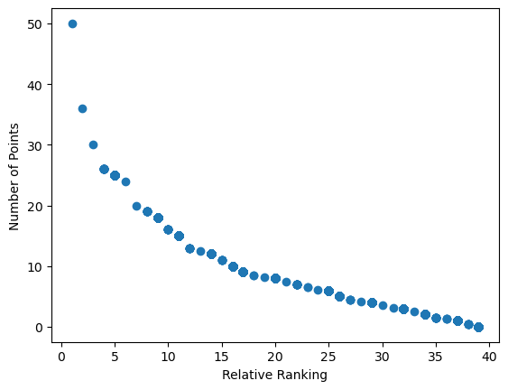

```python
# The graph shows that the winner gets 50 points
plt.scatter(x = results["rank_points"],y = results["points"])
plt.ylabel("Number of Points")
plt.xlabel("Relative Ranking")
```

The following code computes ranks by group

```python
# The subfunction "transform" allows us to pass-along some of the options

results["rank_points_withinteam"] = (results.groupby("constructorId")["points"]
                                            .transform("rank",
                                                       method = "dense",
                                                       ascending = True))
```

***Example***

- Compute a scatter plot with ...
- "points" (y-axis) vs "mean_points" (x-axis)

Note: This plots tells you how much a driver's performance on individual races deviates from their overall average

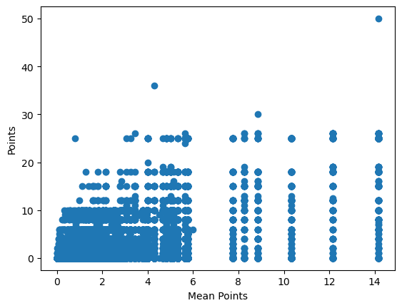

```python
plt.scatter(x = results_merge["mean_points"], y = results_merge["points"])
plt.xlabel("Mean Points")
plt.ylabel("Points")
plt.show()
```

***Example***

- Merge the "teamrace_agg" data into "results"
- This time use the option:

$\qquad$ `on = ["raceId","constructorId"]`

```python
results_teamrace_merge = pd.merge(results,
                                  teamrace_agg,
                                  on = ["raceId", "constructorId"],
                                  how = "left")

len(results_teamrace_merge)
```

```
25840
```

### Merging Data

Before we start merging data, we need to check columns with similar names.

```python
# We extract all the unique values in races_raw["name"] and circuits_raw["name"]
# We use "sort_values()" to make it easier to compare the variables
# The "codebook/f1_codebook.pdf" file shows that the content is indeed different

unique_data_races    = pd.unique(races_raw["name"].sort_values())
unique_data_circuits = pd.unique(circuits_raw["name"].sort_values())
```

We need to rename those similar names so we will not be confused after the merging.

Renaming columns' names, we will use dictionaries.

```python
# We first define the dictionary
# Change the pipe ".rename(...)" to rename the columns
# Dictionaries can flexibly accommodate single values or list after ":"

dict_rename_circuits = {"name": "circuit_name"}
circuits = circuits_raw.rename(columns = dict_rename_circuits)
```

```python
# Extract the column names of the "raw" and "clean" data

print("Old List:")
print(circuits_raw.columns.values)
print("")
print("New List:")
print(circuits.columns.values)
```

```
Old List:
['circuitId' 'circuitRef' 'name' 'location' 'country' 'lat' 'lng' 'alt'
 'url']

New List:
['circuitId' 'circuitRef' 'circuit_name' 'location' 'country' 'lat' 'lng'
 'alt' 'url']
```

***Example***

- Create a dictionary to rename "name" to "race_name"
- Rename this column in the "races_raw" dataset
- Store the output in a new dataset called "races"

```python
dict_rename_race = {"name": "race_name"}
races = races_raw.rename(columns = dict_rename_race)

# Check rename works
print(f"Old names: \n {races_raw.columns.values}\n")
print(f"New names: \n {races.columns.values}")
```

[output not shown]

Now, we can actually start merging data sets!

```python
# We can extract multiple columns of a data set by creating
# a list of those clumns' names.
circuits[["circuitId","circuit_name"]]
```

|  | circuitId | circuit_name |
| --- | --- | --- |
| 0 | 1 | Albert Park Grand Prix Circuit |
| 1 | 2 | Sepang International Circuit |
| 2 | 3 | Bahrain International Circuit |
| 3 | 4 | Circuit de Barcelona-Catalunya |
| 4 | 5 | Istanbul Park |
| ... | ... | ... |
| 72 | 75 | Autódromo Internacional do Algarve |
| 73 | 76 | Autodromo Internazionale del Mugello |
| 74 | 77 | Jeddah Corniche Circuit |
| 75 | 78 | Losail International Circuit |
| 76 | 79 | Miami International Autodrome |

77 rows × 2 columns

Merge datasets

`pd.merge(data1,data2,on,how)`

- Strive to merge only specific columns of data2
- Avoid merging all columns
- Keeping it simple gives you more control over the output

```python
# The "pd.merge()" command combines the information from both datasets
# The first argument is the "primary" datasets
# The second argument is the "secondary" dataset (much include the "on" column)
# The "on" is the common variable that is used for merging
# how = "left" tells Python that the left dataset is the primary one

races_merge = pd.merge(races_raw,
                       circuits[["circuitId","circuit_name"]],
                       on = "circuitId",
                       how = "left")

display(races_merge[["raceId", "circuitId", "circuit_name"]].sort_values(by = "circuitId"))

print(f"Old columns:\n{races.columns.values}\n\nNew columns:\n{races_merge.columns.values}")
```

[output not shown]

1102 rows × 3 columns

```
Old columns:
['raceId' 'year' 'round' 'circuitId' 'race_name' 'date' 'time' 'url'
 'fp1_date' 'fp1_time' 'fp2_date' 'fp2_time' 'fp3_date' 'fp3_time'
 'quali_date' 'quali_time' 'sprint_date' 'sprint_time']

New columns:
['raceId' 'year' 'round' 'circuitId' 'name' 'date' 'time' 'url' 'fp1_date'
 'fp1_time' 'fp2_date' 'fp2_time' 'fp3_date' 'fp3_time' 'quali_date'
 'quali_time' 'sprint_date' 'sprint_time' 'circuit_name']
```

```python
# Another example of merging

results_merge = pd.merge(results_raw,
                         races_raw[["raceId","date"]],
                         on = "raceId",
                         how = "left")

print(f"Old columns:\n{results_raw.columns.values}\n\nNew columns:\n{results_merge.columns.values}")
```

```
Old columns:
['resultId' 'raceId' 'driverId' 'constructorId' 'number' 'grid' 'position'
 'positionText' 'positionOrder' 'points' 'laps' 'time' 'milliseconds'
 'fastestLap' 'rank' 'fastestLapTime' 'fastestLapSpeed' 'statusId']

New columns:
['resultId' 'raceId' 'driverId' 'constructorId' 'number' 'grid' 'position'
 'positionText' 'positionOrder' 'points' 'laps' 'time' 'milliseconds'
 'fastestLap' 'rank' 'fastestLapTime' 'fastestLapSpeed' 'statusId' 'date']
```

If we don't deal with similar names before merging, the `merge` function sill still work.

However, the columns names will be renamed to `column_x` and `column_y` by Python. Sometimes, those names are not self-explanatory enough, and we will be confused by the names afterwards. That's why renaming before merging is very important.

```python
# The following code merges the raw data
# which has the "name" column in "races_raw" and "circuits_raw"

races_merge_pitfall = pd.merge(races_raw,
                               circuits_raw[["circuitId","name"]],
                               on = "circuitId",
                               how = "left")

# Python will internally rename the columns "name_x" (for the left dataset)
# and "name_y" (for the right dataset)

print(races_merge_pitfall.columns.values)
```

```
['raceId' 'year' 'round' 'circuitId' 'name_x' 'date' 'time' 'url'
 'fp1_date' 'fp1_time' 'fp2_date' 'fp2_time' 'fp3_date' 'fp3_time'
 'quali_date' 'quali_time' 'sprint_date' 'sprint_time' 'name_y']
```

***Example***

- Rename the columns "name_x" and "name_y" in the dataset "races_merge_pitfall" to "race_name" and "circuit_name"

$\quad$ HINT: Create a dictionary and use "pd.rename()"

```python
dict_rename_races_pitfall = {"name_x": "race_name","name_y": "circuit_name"}
races_pitfall = races_merge_pitfall.rename(columns = dict_rename_races_pitfall)

# Check the rename works
print(f"Old columns:\n{races_merge_pitfall.columns.values}\n\nNew columns:\n{races_pitfall.columns.values}")
```

```
Old columns:
['raceId' 'year' 'round' 'circuitId' 'name_x' 'date' 'time' 'url'
 'fp1_date' 'fp1_time' 'fp2_date' 'fp2_time' 'fp3_date' 'fp3_time'
 'quali_date' 'quali_time' 'sprint_date' 'sprint_time' 'name_y']

New columns:
['raceId' 'year' 'round' 'circuitId' 'race_name' 'date' 'time' 'url'
 'fp1_date' 'fp1_time' 'fp2_date' 'fp2_time' 'fp3_date' 'fp3_time'
 'quali_date' 'quali_time' 'sprint_date' 'sprint_time' 'circuit_name']
```

***Example***

- Merge the column "alt", "long", and "lat" into the races data using "pd.merge()

```python
races_merge_location = pd.merge(races,
                                circuits[["circuitId", "alt", "lng", "lat"]],
                                on = "circuitId",
                                how = "left")

# Check the merge works
print(f"Old columns:\n{races.columns.values}\n\nNew columns:\n{races_merge_location.columns.values}")
```

```
Old columns:
['raceId' 'year' 'round' 'circuitId' 'race_name' 'date' 'time' 'url'
 'fp1_date' 'fp1_time' 'fp2_date' 'fp2_time' 'fp3_date' 'fp3_time'
 'quali_date' 'quali_time' 'sprint_date' 'sprint_time']

New columns:
['raceId' 'year' 'round' 'circuitId' 'race_name' 'date' 'time' 'url'
 'fp1_date' 'fp1_time' 'fp2_date' 'fp2_time' 'fp3_date' 'fp3_time'
 'quali_date' 'quali_time' 'sprint_date' 'sprint_time' 'alt' 'lng' 'lat']
```

Similar to merging, we can CONCAT data sets.

To prepare concatenate, use ".query()" to split data into different parts

```python
circuits_spain = circuits.query('country == "Spain"')
circuits_usa   = circuits.query('country == "United States" | country == "USA"')
circuits_malaysia = circuits.query('country == "Malaysia"')
```

Then, we will concatenate data back together

- Useful if there are datasets split by geography...
- year, or other subgroup

```python
# Works best if columns are identical
# There are also other advanced options if they are not
# https://pandas.pydata.org/docs/reference/api/pandas.concat.html

circuits_concat = pd.concat([circuits_spain, circuits_usa])
```

***Example***

- Concatenate the USA and Malaysia datasets

```python
circuits_concat_usMalaysia = pd.concat([circuits_usa, circuits_malaysia])
```

### Practicing Chaining

We have previously encountered the concept of **chaining** (or **piping**), but in this section, we will formally practice our ability to code using chaining.

```python
# In preperation, create a new column in results
results["points col"] = results["points"]
```

**Review Dataset Operations**

See attached file for a refresher on syntax

Full list: https://www.w3schools.com/python/pandas/pandas_ref_dataframe.asp

The operations with "." are read left to right

- Combine any of the above operations
- Great way to make code efficient
- The sky's the limit!

***Example***

Subsetting **before** extracting columns

```python
results.query('points >= 20')[["driverId","points"]]
```

|  | driverId | points |
| --- | --- | --- |
| 20320 | 4 | 25.0 |
| 20344 | 18 | 25.0 |
| 20368 | 20 | 25.0 |
| 20392 | 18 | 25.0 |
| 20416 | 17 | 25.0 |
| ... | ... | ... |
| 25740 | 830 | 25.0 |
| 25760 | 830 | 25.0 |
| 25780 | 830 | 25.0 |
| 25800 | 847 | 26.0 |
| 25820 | 830 | 25.0 |

262 rows × 2 columns

***Example***

Subsetting **before** aggregating

```python
# This obtains a subset of drivers who competed in races 500 onwards
# then computes the average by team ("constructorId")

(results.query('raceId >= 500')
        .groupby("constructorId")
        .agg(mean_points = ("points","mean")))
```

| constructorId | mean_points |
| --- | --- |
| 1 | 3.148148 |
| 3 | 1.904924 |
| 4 | 1.903226 |
| 5 | 1.203911 |
| 6 | 4.910966 |
| ... | ... |
| 209 | 0.012821 |
| 210 | 0.809028 |
| 211 | 3.723684 |
| 213 | 2.327869 |
| 214 | 3.693182 |

176 rows × 1 columns

***Example***

Subsetting **after** aggregating

```python
# This obtains the average points by team ("constructorId"), then
# produces a subset of team whose average is higher than 10

(results.groupby("constructorId")
        .agg(mean_points = ("points","mean"))
        .query('mean_points >= 10'))
```

| constructorId | mean_points |
| --- | --- |
| 131 | 12.363643 |

***Example***

Chaining inside queries + NaNs

- `is.na()` produces a True/False vector, checking for missing values
- `is.notna()` produces a True/False vector, checking for non-missing values
- `.str.isnumeric()`

```python
# "is.na()" produces a True/False vector, checking for missing values
# "is.notna()" produces a True/False vector, checking for non-missing values
# .str.isnumeric()
results["points"].isna()
results["points"].notna()

subset_nas    = results.query('points.isna()')
subset_nonnas = results.query('points.notna()')
```

## Real-World Applications

### Random Number Simulator

#### The Central Limit Theorem

Consider a sample with $n$ observations

$$ X = \begin{pmatrix} X_1 \\ X_2 \\ \vdots \\ X_n \end{pmatrix}.$$

We can simulate from different distributions

```python
# Set Sample size
# These produce several common distributions
# A normam with "loc" and standard deviation "5"
# A chi-square with "df" degrees of freedom
# A uniform with values between -3 and 5

n = 10000

vec_normal  = np.random.normal(loc = 5, scale = 5, size = n)
vec_chisqr  = np.random.chisquare(df = 1, size = n)
vec_unif    = np.random.uniform(low = -3,high = 5, size = n)
```

The sample average is defined as

$$ \overline{X} = \frac{1}{n}\sum_{i=1}^n X_i $$

```python
print(vec_normal.mean())
print(vec_chisqr.mean())
print(vec_unif.mean())
```

```
5.006422876828413
1.0056585403833294
1.0104836009802556
```

Multiple plots in a row (subplot)

- The normal has more of a bell shape
- The uniform is a rectangular shape

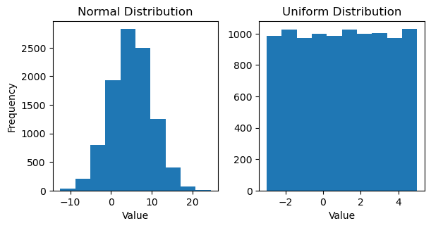

```python
fig, list_subfig = plt.subplots(1, 2,figsize = (6,3))

plt.tight_layout()

list_subfig[0].hist(x = vec_normal)
list_subfig[0].set_title("Normal Distribution")
list_subfig[0].set_xlabel("Value")
list_subfig[0].set_ylabel("Frequency")

list_subfig[1].hist(x = vec_unif)
list_subfig[1].set_title("Uniform Distribution")
list_subfig[1].set_xlabel("Value")
#list_subfig[1].set_ylabel("Frequency")
```

***Excerise***

- Do a version with three plots in the same row
- What happens if you remove the "plt.tight_layout()" command?
- What happens if you change the "figsize"?

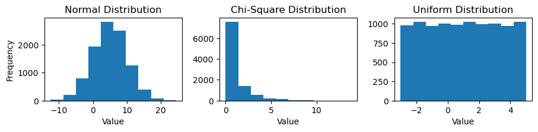

```python
fig, list_subfig = plt.subplots(1, 3, figsize = (9,2))

plt.tight_layout()

list_subfig[0].hist(x = vec_normal)
list_subfig[0].set_title("Normal Distribution")
list_subfig[0].set_xlabel("Value")
list_subfig[0].set_ylabel("Frequency")

list_subfig[1].hist(x = vec_chisqr)
list_subfig[1].set_title("Chi-Square Distribution")
list_subfig[1].set_xlabel("Value")
#list_subfig[1].set_ylabel("Frequency")

list_subfig[2].hist(x = vec_unif)
list_subfig[2].set_title("Uniform Distribution")
list_subfig[2].set_xlabel("Value")
#list_subfig[2].set_ylabel("Frequency")
```

What happens to $\overline{X}$ if we draw different samples?

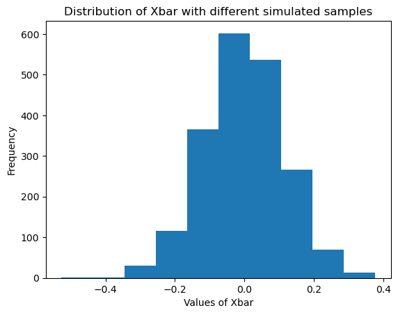

```python
# We will draw random sample "num_simulations" times
# Each time we will create a random vector of size "sample_size"
# In this example we will generate values from a uniform between -2 and 2.

num_simulations = 2000
sample_size     = 100

vec_xbar = [None] * num_simulations

for iteration in range(num_simulations):
    vec_unif  = np.random.uniform(low = -2, high=2, size = sample_size)
    vec_xbar[iteration] = vec_unif.mean()

plt.hist(vec_xbar)
plt.title("Distribution of Xbar with different simulated samples")
plt.ylabel("Frequency")
plt.xlabel("Values of Xbar")
plt.show()
```

What happens to $\overline{X}$ if we draw with different $n$?